# Project Milestone #3

Group 10: Ruby Yun, Jackie Zintel

2026-11-08

Project Milestone #3

Scenario 1: Infectious disease outbreak (simulated) in California

**1. Introduction**

This project uses simulated infectious disease outbreak data from Scenario 1 of the PHW251 Project Data GitHub repository to examine the distribution of infections across California.

Our primary research question is: How did infection rates during the outbreak vary by county, age, sex and race/ethnicity across California?

The datasets include simulated morbidity data from California and Los Angeles County, containing information on new infection cases and individual demographic and geographic characteristics. Additionally, the analysis incorporates 2023 California Department of Finance population estimates. This dataset provide the denominators needed to calculate infection rates per 100,000 population, allowing for more meaningful comparisons across demographic and geographic groups.

By combining morbidity and population data, this project aims to identify variations in infection rates across California counties and demographic groups during the simulated outbreak.

**2. Import dataset**

```r
library(tidyverse)
library(janitor)
library(gt)

#import datasets
getwd()
ca_pop <- read.csv("../phw251_projectdata/scenario_1/ca_pop_2023.csv")
sim_ca <- read.csv("../phw251_projectdata/scenario_1/sim_novelid_CA.csv")
sim_la <- read.csv("../phw251_projectdata/scenario_1/sim_novelid_LACounty.csv")

#clean the column names
ca_pop <- ca_pop %>%
  clean_names()
colnames(ca_pop)

sim_ca <- sim_ca %>%
  clean_names()
colnames(sim_ca)

sim_la <- sim_la %>%
  clean_names()
colnames(sim_la)
```

**3. Data types and variables**

```r
# Identify all the variables in each dataset
sapply(ca_pop, class)
sapply(sim_ca, class)
sapply(sim_la, class)
```

We chose the following variables: - county - age_cat - sex - race_ethnicity - new_infections - population - dt_dignosis

Desired data types for analysis: - county, age category, sex, race/ethnicity, dt_diagnosis: character/categorical - population and new infections: integer/numeric

**4. Data Cleaning**

1. Convert variables
- Rename columns

```r
ca_pop <- ca_pop %>% rename(race_ethnicity = race7)

sim_la <- sim_la %>% rename(new_infections = dx_new,
                            race_ethnicity = race_eth,
                            age_cat = age_category)

sim_la <- sim_la %>%
  rename(
    cumulative_infected = infected_cumulative,
    new_unrecovered = unrecovered_new,
    cumulative_unrecovered = unrecovered_cumulative,
    new_severe = severe_new,
    cumulative_severe = severe_cumulative
  ) %>%
  mutate(
    county = "Los Angeles"
  )

colnames(ca_pop)
colnames(sim_ca)
colnames(sim_la)
```

- Race/ethnicity

```r
sim_ca <- sim_ca %>% mutate(
  race_ethnicity = case_when(
    race_ethnicity == 1 ~ "White NH",
    race_ethnicity == 2 ~ "Black NH",
    race_ethnicity == 3 ~ "AIAN NH",
    race_ethnicity == 4 ~ "Asian NH",
    race_ethnicity == 5 ~ "NHPI NH",
    race_ethnicity == 6 ~ "MR NH",
    race_ethnicity == 7 ~ "Hispanic"
    )
  )

unique(sim_ca$race_ethnicity)

sim_la <- sim_la %>%
  mutate(
    race_ethnicity = case_when(
      race_ethnicity == "White, Non-Hispanic" ~ "White NH",
      race_ethnicity == "Black, Non-Hispanic" ~ "Black NH",
      race_ethnicity == "American Indian or Alaska Native, Non-Hispanic" ~ "AIAN NH",
      race_ethnicity == "Asian, Non-Hispanic" ~ "Asian NH",
      race_ethnicity == "Native Hawaiian or Pacific Islander, Non-Hispanic" ~ "NHPI NH",
      race_ethnicity == "Multiracial (two or more of above races), Non-Hispanic" ~ "MR NH",
      race_ethnicity == "Hispanic (any race)" ~ "Hispanic",
      TRUE ~ race_ethnicity
    ))

unique(sim_la$race_ethnicity)

ca_pop <- ca_pop %>%
  mutate(
    race_ethnicity = recode(
      race_ethnicity,
      "WhiteTE NH" = "White NH"
    )
  )

unique(ca_pop$race_ethnicity)
```

- County names

```r
sim_ca$county <- str_remove(sim_ca$county, " County$")

unique(sim_la$county)
unique(sim_ca$county)
unique(ca_pop$county)
```

2. Recategorize age groups

```r
ca_pop <- ca_pop %>%
  mutate(age_cat = case_when(
    age_cat %in% c("0-4", "5-11", "12-17") ~ "0-17",
    .default = age_cat)
  )

unique(ca_pop$age_cat)
```

```
## [1] "0-17"  "18-49" "50-64" "65+"
```

```r
unique(sim_ca$age_cat)
```

```
## [1] "0-17"  "18-49" "50-64" "65+"
```

```r
unique(sim_la$age_cat)
```

```
## [1] "0-17"  "18-49" "50-64" "65+"
```

3. Standardize dates

```r
library(lubridate)
# Convert sim_ca date (YYYY-MM-DD)
sim_ca <- sim_ca %>%
  mutate(dt_diagnosis = ymd(dt_diagnosis))

# Convert sim_la date (DDMMMYYYY)
sim_la <- sim_la %>%
  mutate(dt_dx = dmy(dt_dx))

sim_la <- sim_la %>%
  rename(dt_diagnosis = dt_dx)

unique(sim_ca$dt_diagnosis)
unique(sim_la$dt_diagnosis)
```

**5. Merge the datasets**

1. Combine sim_ca and sim_la in one dataset

```r
sim_combined <- bind_rows(
  sim_ca,
  sim_la
)

dim(sim_ca)
```

```
## [1] 98952    12
```

```r
dim(sim_la)
```

```
## [1] 1736   12
```

```r
dim(sim_combined)
```

```
## [1] 100688     13
```

2. Join population dataset

```r
# summarize ca_pop dataset before merging
ca_pop_clean <- ca_pop %>%
  group_by(
    county,
    age_cat,
    sex,
    race_ethnicity
  ) %>%
  summarise(
    population = sum(pop, na.rm = TRUE),
    .groups = "drop"
  )

glimpse(ca_pop_clean)

# combine all datasets into one dataset
combined_df <- sim_combined %>%
  left_join(
    ca_pop_clean,
    by = c(
      "county",
      "age_cat",
      "sex",
      "race_ethnicity"
    ),
    relationship = "many-to-one"
  )

glimpse(combined_df)
```

**6. Data analysis**

There are extra variables that we don’t need in order to answer our research question. We simplified it to only include relevant information:

1. Select relevant information

```r
selected_df <- combined_df %>%
  select(
    county,
    age_cat,
    sex,
    race_ethnicity,
    dt_diagnosis,
    new_infections,
    population
  )

glimpse(selected_df)
```

2. Check missing values

```r
# check missing values
colSums(is.na(selected_df))
```

```
##         county        age_cat            sex race_ethnicity   dt_diagnosis
##              0              0              0              0              0
## new_infections     population
##              0              0
```

```r
# check invalid values
sum(selected_df$new_infections < 0, na.rm = TRUE)
```

```
## [1] 0
```

```r
sum(selected_df$population <= 0, na.rm = TRUE)
```

```
## [1] 1426
```

```r
# count unique strata with invalid population values (<= 0)
selected_df %>%
  filter(population <= 0) %>%
  distinct(county, age_cat, sex, race_ethnicity, population) %>%
  nrow()
```

```
## [1] 46
```

3. Create new variables
- Create a month variable to examine monthly infection trends

```r
selected_df <- selected_df %>%
  mutate(diagnosis_month = month(dt_diagnosis, label = TRUE, abbr = TRUE)) %>%
  select(-dt_diagnosis)

head(selected_df)
```

```
##    county age_cat    sex race_ethnicity new_infections population
## 1 Alameda    0-17 FEMALE       White NH              6      34155
## 2 Alameda    0-17 FEMALE       White NH              1      34155
## 3 Alameda    0-17 FEMALE       White NH              2      34155
## 4 Alameda    0-17 FEMALE       White NH             10      34155
## 5 Alameda    0-17 FEMALE       White NH             19      34155
## 6 Alameda    0-17 FEMALE       White NH             25      34155
##   diagnosis_month
## 1             May
## 2             Jun
## 3             Jun
## 4             Jun
## 5             Jun
## 6             Jul
```

- Calculate infection rates

```r
aggregated_df <- selected_df %>%
  group_by(county, age_cat, sex, race_ethnicity) %>%
  summarize(
    total_infections = sum(new_infections, na.rm = TRUE),
    population = first(population),
    .groups = "drop"
  ) %>%
  mutate(
    infection_rate = if_else(
      population > 0,
      round(total_infections / population * 100000, 1),
      NA_real_
      )
    )

head(aggregated_df)
```

```
## # A tibble: 6 × 7
##   county age_cat sex   race_ethnicity total_infections population infection_rate
##   <chr>  <chr>   <chr> <chr>                     <int>      <int>          <dbl>
## 1 Alame… 0-17    FEMA… AIAN NH                      16        533          3002.
## 2 Alame… 0-17    FEMA… Asian NH                   1090      52080          2093.
## 3 Alame… 0-17    FEMA… Black NH                    486      14149          3435.
## 4 Alame… 0-17    FEMA… Hispanic                   1390      46446          2993.
## 5 Alame… 0-17    FEMA… MR NH                       354      15881          2229.
## 6 Alame… 0-17    FEMA… NHPI NH                      32       1321          2422.
```

**7. Data visualization**

Some observations had a population value of zero across multiple counties. Since population is used as the denominator when calculating infection rates, these observations cannot produce a valid rate. Therefore, observations with a population value of zero were excluded from the graphs and rate calculations only. The original dataset was retained without deleting these observations.

1. Monthly infection trend in California

```r
df_monthly <- selected_df %>%
  filter(population > 0) %>%
  group_by(diagnosis_month) %>%
  summarize(total_infections = sum(new_infections, na.rm = TRUE),
            .groups = "drop")

df_monthly %>% gt()
```

| diagnosis_month | total_infections |
| --- | --- |
| May | 13875 |
| Jun | 119964 |
| Jul | 440528 |
| Aug | 936490 |
| Sep | 1445805 |
| Oct | 1403725 |
| Nov | 181326 |
| Dec | 7863 |

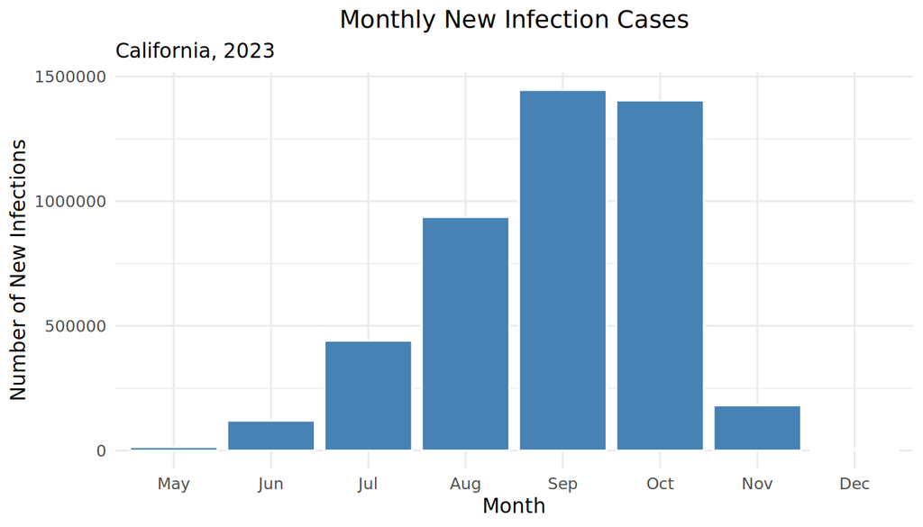

```r
ggplot(df_monthly,
       aes(x = diagnosis_month, y = total_infections)) +
  geom_col(fill = "steelblue", color = "white") +
  labs(title = "Monthly New Infection Cases",
       subtitle = "California, 2023",
       x = "Month",
       y = "Number of New Infections") +
  theme_minimal() +
  theme(plot.title = element_text(hjust = 0.5))
```

2. Infection rate by county

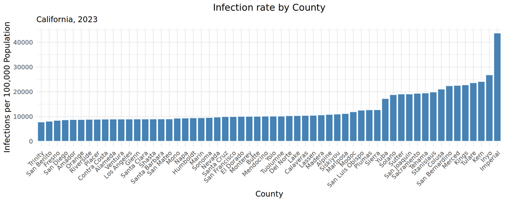

```r
df_county <- aggregated_df %>%
  filter(population > 0) %>%
  group_by(county) %>%
  summarize(total_infections = sum(total_infections),
            population = sum(population),
            .groups = "drop") %>%
  mutate(
    infection_rate = round
    (total_infections/population * 100000, 1)
         )

ggplot(df_county,
       aes(x = reorder(county, infection_rate), y = infection_rate)) +
  geom_col(fill = "steelblue", color = "white") +
  labs(title = "Infection rate by County",
       subtitle = "California, 2023",
       x = "County",
       y = "Infections per 100,000 Population") +
  theme_minimal() +
  theme(axis.text.x = element_text(angle = 45, hjust = 1),
        plot.title = element_text(hjust = 0.5))
```

3. Infection rate by age group and sex

```r
df_age_sex <- aggregated_df %>%
  filter(population > 0) %>%
  group_by(age_cat, sex) %>%
  summarize(total_infections = sum(total_infections),
            population = sum(population),
            .groups = "drop") %>%
  mutate(
    infection_rate = round
    (total_infections/population * 100000, 1)
         )

df_age_sex %>% gt()
```

| age_cat | sex | total_infections | population | infection_rate |
| --- | --- | --- | --- | --- |
| 0-17 | FEMALE | 172556 | 4305052 | 4008.2 |
| 0-17 | MALE | 180653 | 4389059 | 4116.0 |
| 18-49 | FEMALE | 1193623 | 8535362 | 13984.4 |
| 18-49 | MALE | 1273661 | 8571143 | 14859.9 |
| 50-64 | FEMALE | 274356 | 3631197 | 7555.5 |
| 50-64 | MALE | 266123 | 3455600 | 7701.2 |
| 65+ | FEMALE | 653627 | 3459786 | 18892.1 |
| 65+ | MALE | 534977 | 2761871 | 19370.1 |

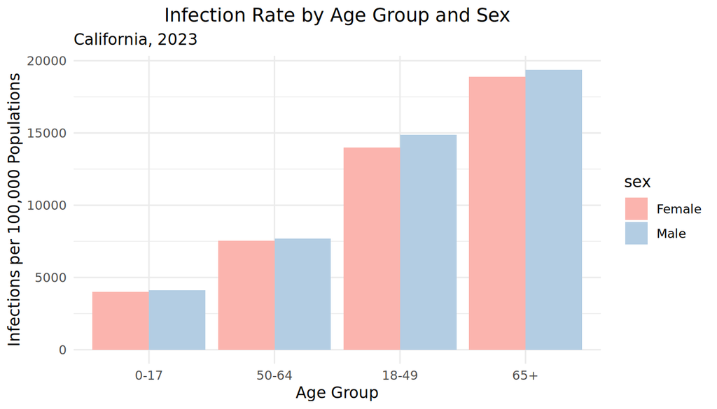

```r
ggplot(df_age_sex,
       aes(x = reorder(age_cat, infection_rate),
           y = infection_rate,
           fill = sex)) +
  geom_col(position = "dodge") +
  scale_fill_brewer(palette = "Pastel1",
                    labels = c("Female", "Male")) +
  labs(
    title = "Infection Rate by Age Group and Sex",
    subtitle = "California, 2023",
    x = "Age Group",
    y = "Infections per 100,000 Populations"
  ) +
  theme_minimal() +
  theme(plot.title = element_text(hjust = 0.5)
        )
```

4. Infection rate by race/ethnicity

```r
df_race <- aggregated_df %>%
  filter(population > 0) %>%
  group_by(race_ethnicity) %>%
  summarize(
    total_infections = sum(total_infections),
    population = sum(population),
    .groups = "drop"
  ) %>%
  mutate(
    infection_rate = round
    (total_infections / population * 100000, 1)
  )

df_race %>% gt()
```

| race_ethnicity | total_infections | population | infection_rate |
| --- | --- | --- | --- |
| AIAN NH | 22195 | 158672 | 13988.0 |
| Asian NH | 546768 | 6295420 | 8685.2 |
| Black NH | 271836 | 2211518 | 12291.8 |
| Hispanic | 1796695 | 14829946 | 12115.3 |
| MR NH | 116391 | 1611503 | 7222.5 |
| NHPI NH | 16917 | 153729 | 11004.4 |
| White NH | 1778774 | 13848282 | 12844.7 |

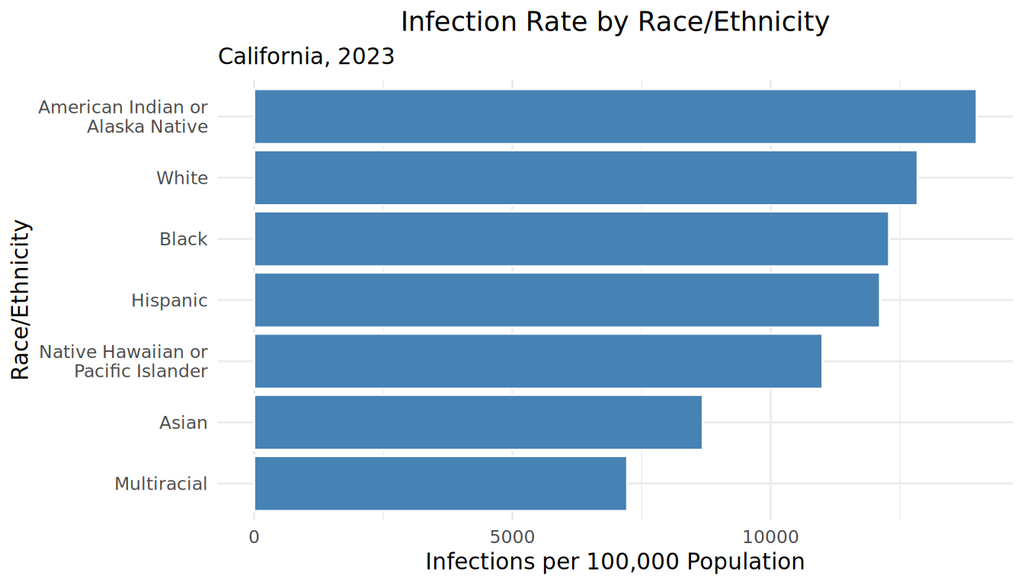

```r
ggplot(df_race,
       aes(x = reorder(race_ethnicity, infection_rate),
           y = infection_rate)) +
  geom_col(fill = "steelblue", color = "white") +
  scale_x_discrete(labels = c(
"White NH" = "White",
"Black NH" = "Black",
"AIAN NH" = "American Indian or\nAlaska Native",
"Asian NH" = "Asian",
"NHPI NH" = "Native Hawaiian or\nPacific Islander",
"MR NH" = "Multiracial",
"Hispanic" = "Hispanic"
  )) +
  labs(
    title = "Infection Rate by Race/Ethnicity",
    subtitle = "California, 2023",
    x = "Race/Ethnicity",
    y = "Infections per 100,000 Population"
  ) +
  coord_flip() +
  theme_minimal() +
  theme(
    plot.title = element_text(hjust = 0.5)
  )
```

**8. Data Dictionary**

1. Basic description provided for all variables
- county: county names
- age_cat: age category “0-17” “18-49” “50-64” “65+”
- sex: male/female
- race_ethnicity: race/ethnicity categorization as defined by CA Dept of Finance “White NH” = “White, Non-Hispanic” “Black NH” = “Black, Non-Hispanic” “AIAN NH” = “American Indian or Alaska Native, Non-Hispanic” “Asian NH” = “Asian, Non-Hispanic” “NHPI NH” = “Native Hawaiian or Pacific Islander, Non-Hispanic” “MR NH” = “Multiracial (two or more of above races), Non-Hispanic” “Hispanic” = “Hispanic (any race)”
- new_infections: number of newly diagnosed individuals
- population: CA Dept of Finance estimated all ages population for year 2023
- diagnosis_month: the month when infections were diagnosed
2. Demographic information (county, age category, sex, race/ethnicity)

```r
str(selected_df)
```

```r
data_dictionary <- tibble(
  Variable_Name = c(
    "county",
    "age_cat",
    "sex",
    "race_ethnicity",
    "new_infections",
    "population",
    "diagnosis_month"
  ),
  Data_Type = c(
    "Character",
    "Character",
    "Character",
    "Character",
    "Integer",
    "Integer",
    "Ordered Factor"
  ),
  Description = c(
    "California county where infections were reported",
    "Age category of the population",
    "Sex of the population",
    "Race and ethnicity classification",
    "Number of new infection cases",
    "Population size for each demographic group",
    "Month when infections were diagnosed"
  ),
  Constraints = c(
    "Valid California county name",
    "Standardized age categories",
    "Female or Male",
    "Standardized race/ethnicity categories",
    "Non-negative integer",
    "Positive integer",
    "May through December in chronological order"
  )
)

data_dictionary %>% gt()
```

| Variable_Name | Data_Type | Description | Constraints |
| --- | --- | --- | --- |
| county | Character | California county where infections were reported | Valid California county name |
| age_cat | Character | Age category of the population | Standardized age categories |
| sex | Character | Sex of the population | Female or Male |
| race_ethnicity | Character | Race and ethnicity classification | Standardized race/ethnicity categories |
| new_infections | Integer | Number of new infection cases | Non-negative integer |
| population | Integer | Population size for each demographic group | Positive integer |
| diagnosis_month | Ordered Factor | Month when infections were diagnosed | May through December in chronological order |

3. Descriptive statistics (new infections, population)

```r
descriptive_stat <- selected_df %>%
  summarize(
    number_of_counties = n_distinct(county),
    number_of_age_categories = n_distinct(age_cat),
    number_of_race_ethnicity_categories = n_distinct(race_ethnicity),
    mean_infections = mean(new_infections, na.rm = TRUE),,
    median_infections = median(new_infections, na.rm = TRUE),
    max_infections = max(new_infections, na.rm = TRUE),
    mean_population = mean(population, na.rm = TRUE),
    median_population = median(population, na.rm = TRUE)
  ) %>%
  pivot_longer(cols = everything(),
               names_to = "statistics",
               values_to = "value") %>%
  mutate(value = round(value, 1))

descriptive_stat %>% gt()
```

| statistics | value |
| --- | --- |
| number_of_counties | 58.0 |
| number_of_age_categories | 4.0 |
| number_of_race_ethnicity_categories | 7.0 |
| mean_infections | 45.2 |
| median_infections | 1.0 |
| max_infections | 12110.0 |
| mean_population | 12041.0 |
| median_population | 683.5 |

4. Relationships and findings

The four tables and graphs illustrate how the simulated infectious disease outbreak varied over time, geographically, and across demographic groups in California.

Monthly new infections increased steadily from May through September, reaching their peak in September before declining in October and November. This pattern suggests that the outbreak intensified throughout the summer months before beginning to subside in the fall.

County-level infection rates revealed geographic differences in disease burden. Imperial, Inyo, Kern, and Tulare counties had some of the highest infection rates per 100,000 residents. These counties generally have smaller populations than California’s largest metropolitan counties, highlighting the importance of using population-adjusted infection rates rather than absolute case counts when comparing disease burden across geographic areas.

Together, these findings demonstrate that the simulated outbreak was not evenly distributed across California’s population. While the monthly trends show when infections were most prevalent, the county and demographic analyses identify which populations experienced the highest infection rates.

**Morbidity datasets (from CA and LA County) - Recode column names, values, or formats that are in discordant - Ruby - Combine morbidity datasets into a single dataset - Jackie - Select demographic and geographic strata (s) of interest - Ruby - Aggregate the data into a new dataframe to include only one row per strata of interest - Ruby

**Population dataset - Recode values to be consistent with morbidity datasets so they can be joined - Ruby - Select demographic or geographic strata(s) of interest: county, age, sex, and race - Jackie - Create a rate metric and summarize to include only one row per strata of interest: new infection cases by demographic or geographic strata -> use `summarize()` and `group_by()` - Jackie & Ruby

*Subset rows or columns, as needed - Jackie* Create new variables needed for analysis (minimum 2): new variables should be created based on existing columns - Jackie & Ruby *Clean variables needed for analysis (minimum 2) - Jackie & Ruby - Recode invalid values - Jackie - Handle missing data - Jackie & Ruby - Recode categories - Jackie & Ruby* Data re-structured as needed (aggregated/summarized and/or pivoted) - Jackie & Ruby

*Data dictionary based on clean dataset (minimum 4 data elements), including variable name, data type, and description - Table & Field Names: The exact names used in the database - Ruby - Data Types: What kind (type, class) of data is allowed - Ruby - Descriptions/Definitions: A clear explanation of what each field represents - Ruby - Constraints & Rules: Restrictions on the data - Ruby - Relationships: How tables connect to one another - Jackie

*One or more tables with descriptive statistics for 4 data elements - Ruby - Tables + ggplot2

*Html output that is professionally prepared for presentation - Only the necessary information is outputted - Ruby (use `echo=TRUE` and `results='hide'` for some unnecessary outputs) - Use of headers and sub headers to create an organized document - Ruby